# IST736_Victorization_WK2

## Author: Beverlyn Tucker

## Professor: Dr. Ami Gates

## IST736_ Text Mining WK2 Vectorizing

## Introduction

Applications of text mining encompass a broad and general field, often impartial to programming languages. Today scripting languages such as Python and R, and other tools like such as Java, have many related utilities. Some popular non-commercial frameworks in python, including the natural language toolkit (NTLK), provide nearly all capabilities for data scientists and engineers. However, infrequent edge cases occur, sometimes requiring a unique approach, while other times, borrowing solutions elsewhere. While diversification in tools often overlaps in functionality, novel features can often complement another framework. The art of optimizing tools is generally an engineering constraint.

Being able to mold different frameworks utilizing the right combination of features is an art requiring a degree of experience. Business objectives often driven requirements, and inherently suggest approaches for storytelling. Moreover, if visualization is contingent on multiple engineering constraints at scale, diverse technology and framework knowledge is invaluable.

## Data Preparation

```python
# Import required packages for data upload, preparation, and vectorization
import pandas as pd
import numpy as np
from pandas import DataFrame
from sklearn.feature_extraction.text import CountVectorizer
from sklearn.feature_extraction.text import TfidfVectorizer
from nltk.stem.snowball import EnglishStemmer
import re
```

```python
# Load the data set
tweets = pd.read_csv("C:/Users/bevst/Downloads/IST736/AI_Tweets.csv", encoding='cp1252')
```

```python
# Isolate the tweets in a corpus list
corpus = tweets['text']
corpus.head()
```

```
0    Artificial Intelligence Is Going To Be The End...
1    The Weaponization Of Artificial Intelligence #...
2    The Weaponization Of Artificial Intelligence #...
3    @TheChameleon84 wow. I hate Artificial Intelli...
4    this artificial intelligence performance kind ...
Name: text, dtype: object
```

## Initial Data Cleaning

Create a count vectorizer that drops any word that contains a number

```python
# Isolate the tweets in a corpus list
corpus = tweets['text']

cv = CountVectorizer(token_pattern=r'\b[^\d\W]+\b')
Xcv = cv.fit_transform(corpus)

# Create a TF-IDF vectorizer to compare results.
tfidf = TfidfVectorizer(token_pattern=r'\b[^\d\W]+\b')
Xti = tfidf.fit_transform(corpus)
```

## Compare As Base Line Dictionary

Count Vectorizer and TF-IDF Vectorizer words in dictionary

```python
# Print length of the dictionaries to serve as a baseline.
print("Count Vectorizer words in dictionary: %s" % len(cv.get_feature_names()))
print('TF-IDF Vectorizer words in dictionary: %s' % len(tfidf.get_feature_names()))
```

```
Count Vectorizer words in dictionary: 1298
TF-IDF Vectorizer words in dictionary: 1298
```

## Data Cleaning removing stop words and words contain numbers

```python
# Second count vectorizer
cv2 = CountVectorizer(token_pattern=r'\b[^\d\W]+\b', stop_words='english')
Xcv2 = cv2.fit_transform(corpus)

# Second tf-idf vectorizer
tfidf2 = TfidfVectorizer(token_pattern=r'\b[^\d\W]+\b', stop_words='english')
Xti2 = tfidf2.fit_transform(corpus)

# Dictionary length.
print('Count Vectorizer without stop words: %s' % len(cv2.get_feature_names()))
print('TF-IDF Vectorizer without stop words: %s' % len(tfidf2.get_feature_names()))
```

```
Count Vectorizer without stop words: 1155
TF-IDF Vectorizer without stop words: 1155
```

## After Data Cleaning

Vectorizer Results booth Count Vectorizer and TF-IDF Vectorizer with total 1155 words dictionary.

## Maximize the loading time utilized Stemmer

A function that stems every word in the corpus. Loops over every word to find the stemmed word for faster computation.

```python
# package from the NLTK
stemmer = EnglishStemmer()

# Builds Count and TF-IDF analyzers that consider patterns and stop words.
cv3 = CountVectorizer(token_pattern=r'\b[^\d\W]+\b', stop_words='english').build_analyzer()
tfidf3 = TfidfVectorizer(token_pattern=r'\b[^\d\W]+\b', stop_words='english').build_analyzer()

print(tfidf3)

# Loops over every word to find the stemmed word for faster computation
def stemmed_cv_words(doc):
    return (stemmer.stem(w) for w in cv3(doc))

def stemmed_tfidf_words(doc):
    return (stemmer.stem(w) for w in tfidf3(doc))

# Final vectorizer that outputs dictionary lengths
cv_stem = CountVectorizer(analyzer=stemmed_cv_words)
cv3 = cv_stem.fit_transform(corpus)

tfidf_stem = TfidfVectorizer(analyzer=stemmed_tfidf_words)
tfidf3 = tfidf_stem.fit_transform(corpus)

##print(tfidf3)

print('Stemmed Count Vectorizer: %s' % len(cv_stem.get_feature_names()))
print('Stemmed TF-IDF Vectorizer: %s' % len(tfidf_stem.get_feature_names()))
```

```
functools.partial(<function _analyze at 0x00000207D6FA2EE8>, ngrams=<bound method _VectorizerMixin._word_ngrams of TfidfVectorizer(stop_words='english', token_pattern='\\b[^\\d\\W]+\\b')>, tokenizer=<built-in method findall of re.Pattern object at 0x00000207D8B96870>, preprocessor=functools.partial(…
Stemmed Count Vectorizer: 1047
Stemmed TF-IDF Vectorizer: 1047
```

```python
print(cv3)
```

[output not shown]

```python
print(tfidf3)
```

[output not shown]

## Results after Stemming Process

Count Vectorizer and TF-IDF Vectorizer both reduce to significant amount from 1155 to 1047 counts

## Plot top10 Vectorizers

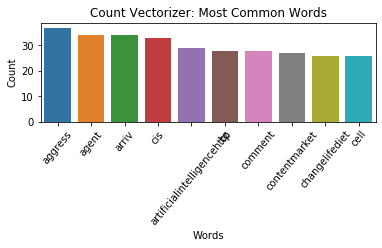

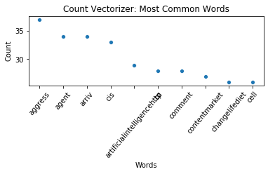

```python
import seaborn as sns
import matplotlib.pyplot as plt

# Gets the labels and sum of words for Count Vectorizer. Then, we convert to Pandas series
# and Data top10 most common words.
# Finally, we plot the most common words to see how the vectorizer has stemmed the words.
cv_labels, cv_values = cv_stem.get_feature_names(), cv3.sum(axis=1)
cv_labels = pd.Series(cv_labels)
cv_values = pd.DataFrame(cv_values)
cv_count = pd.concat([cv_labels, cv_values], axis=1, ignore_index=True)
cv_count.columns = ['labels', 'values']
cv_count = cv_count.sort_values(by=['values'], ascending=False)

cv_count_top10 = cv_count[:10]

# Plot the vectorizers for visual comparison.
plt.subplot(2, 1, 1)
sns.barplot(x='labels', y='values', data=cv_count_top10)
_ = plt.xlabel('Words')
_ = plt.xticks(rotation=50)
_ = plt.ylabel('Count')
_ = plt.title('Count Vectorizer: Most Common Words')
plt.show()


# Plot the vectorizers for visual comparison.
plt.subplot(2, 1, 2)
sns.scatterplot(x='labels', y='values', data=cv_count_top10)
_ = plt.xlabel('Words')
_ = plt.xticks(rotation=50)
_ = plt.ylabel('Count')
_ = plt.title('Count Vectorizer: Most Common Words')
plt.show()
```

```python
print(cv_count_top10)
```

```
                         labels  values
19                      aggress    37.0
18                        agent    34.0
46                        arriv    34.0
157                         cis    33.0
52   artificialintelligencehttp    29.0
127                          bz    28.0
171                     comment    28.0
183               contentmarket    27.0
144              changelifediet    26.0
138                        cell    26.0
```

## Plot top10 TF-IDF Vectorizer

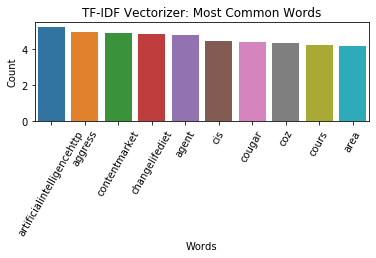

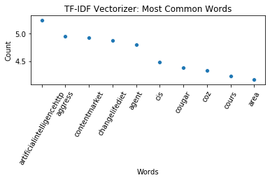

```python
# Repeat the process for the TF-IDF Vectorizer.
tfidf_labels, tfidf_values = tfidf_stem.get_feature_names(), tfidf3.sum(axis=1)
tfidf_labels = pd.Series(tfidf_labels)
tfidf_values = pd.DataFrame(tfidf_values)
tfidf_count = pd.concat([tfidf_labels, tfidf_values], axis=1, ignore_index=True)
tfidf_count.columns = ['labels', 'values']
tfidf_count = tfidf_count.sort_values(by=['values'], ascending=False)

# Select the top ten most common words to verify if the vectorizers are splitting the same way.
tfidf_count_top10 = tfidf_count[:10]

plt.subplot(2, 1, 2)
sns.barplot(x='labels', y='values', data=tfidf_count_top10)
_ = plt.xlabel('Words')
_ = plt.xticks(rotation=60)
_ = plt.ylabel('Count')
_ = plt.title('TF-IDF Vectorizer: Most Common Words')
plt.show()



plt.subplot(2, 1, 2)
sns.scatterplot(x='labels', y='values', data=tfidf_count_top10)
_ = plt.xlabel('Words')
_ = plt.xticks(rotation=60)
_ = plt.ylabel('Count')
_ = plt.title('TF-IDF Vectorizer: Most Common Words')
plt.show()
```

```python
print(tfidf_count_top10)
```

```
                         labels    values
52   artificialintelligencehttp  5.233419
19                      aggress  4.953681
183               contentmarket  4.922485
144              changelifediet  4.868394
18                        agent  4.800896
157                         cis  4.484779
191                      cougar  4.381120
195                         coz  4.331427
193                       cours  4.233353
43                         area  4.164053
```

```python
from sklearn.model_selection import train_test_split
# Convert label back to int.
#df2['Analysis'] = df['Analysis'].astype('int')
# Split the data into train and test sets.
np.random.seed(42)
x_train, x_test, y_train, y_test = train_test_split(df2['tweets'], df2['Analysis'], test_size=0.33, random_state=5)
```

```python
from sklearn.feature_extraction.text import CountVectorizer, TfidfTransformer
from sklearn.decomposition import PCA
from sklearn.pipeline import Pipeline
import matplotlib.pyplot as plt

newsgroups_train = fetch_20newsgroups(subset='train',
                                      categories=['alt.atheism', 'sci.space'])
pipeline = Pipeline([
    ('vect', CountVectorizer()),
    ('tfidf', TfidfTransformer()),
])
X = pipeline.fit_transform(newsgroups_train.data).todense()

pca = PCA(n_components=2).fit(X)
data2D = pca.transform(X)
plt.scatter(data2D[:,0], data2D[:,1], c=data.target)
plt.show()
```

[output not shown]

A significant drop in the number of terms.

```python
cv_count2 = cv_count[cv_count['values'] >= 2]
tfidf_count2 = tfidf_count[tfidf_count['values'] >= 2]

print('Count Vectorizer Min Term 2: %s' % len(cv_count2))
print('TF-IDF Vectorizer Min Term 2: %s' % len(tfidf_count2))
```

```
Count Vectorizer Min Term 2: 199
TF-IDF Vectorizer Min Term 2: 187
```

## Results

After multiple iterations, TF-IDF is more restrictive as it is weighing the terms based on the rest of the term frequencies in the corpus, making it much more stringent.

## Conclusion

Conducting analysis frequently requires skills and the wisdom to select effective methodologies. Without applying foundational principles for data preparation and associated analysis, could risk time management.

Text mining is an exciting field for data scientists and engineers. Non-commercial packages and utilities allow coding challenges to be abstracted. Moreover, numerous off-shelf solutions require knowledge to select the right combination of frameworks. Often, the acumen in engineering a problem (or lack of), is noticeable within the associated results. Furthermore, in the area of text mining and NLP, the combination of tokenization and vectorization, provide data scientists room for creativity